# UAS VISUALISASI DATA

Fazlur Rahman Hafidh-Institut Teknologi Statistika dan Bisnis Muhammadiyah

2025-01-29

## Membaca dataset dari file Excel dan menampilkan beberapa baris pertama.

```r
library(readxl)
data <- read_excel("E:/DATA VISUALITATION/UAS---Visualisai-Data/Data.xlsx")
```

```r
head(data)
```

| geo | Negara | Benua | Tahun | Angka_Harapan_Hidup | Pendapatan_per_kapita | Populasi | Jumlah_anak |
| --- | --- | --- | --- | --- | --- | --- | --- |
| afg | Afghanistan | asia | 1800 | 28.21 | 480.7548 | 3280000 | 7 |
| afg | Afghanistan | asia | 1801 | 28.20 | 480.7548 | 3280000 | 7 |
| afg | Afghanistan | asia | 1802 | 28.19 | 480.7548 | 3280000 | 7 |
| afg | Afghanistan | asia | 1803 | 28.18 | 480.7548 | 3280000 | 7 |
| afg | Afghanistan | asia | 1804 | 28.17 | 480.7548 | 3280000 | 7 |
| afg | Afghanistan | asia | 1805 | 28.16 | 480.7548 | 3280000 | 7 |

## Grafik Univariat

# Distribusi Angka Harapan Hidup

Visualisasi ini menunjukkan distribusi Angka Harapan Hidup menggunakan histogram. Histogram ini dibuat dengan menentukan binwidth sebesar 1 untuk mendapatkan distribusi yang lebih halus.

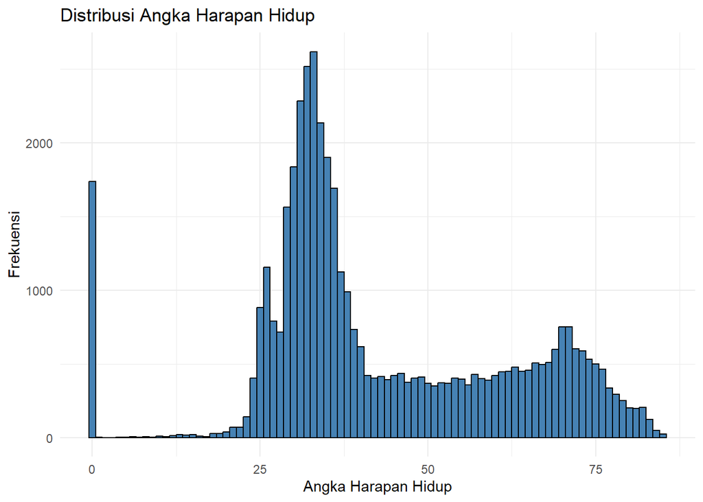

```r
library(ggplot2)
ggplot(data, aes(x = Angka_Harapan_Hidup)) +
  geom_histogram(binwidth = 1, fill = "steelblue", color = "black") +
  labs(title = "Distribusi Angka Harapan Hidup",
       x = "Angka Harapan Hidup",
       y = "Frekuensi") +
  theme_minimal()
```

Interpretasi: Histogram ini membantu kita memahami bagaimana angka harapan hidup tersebar di berbagai negara. Kita dapat melihat apakah distribusi cenderung normal atau ada pola tertentu.

## Grafik Bivariat

# Hubungan Pendapatan per Kapita dan Angka Harapan Hidup

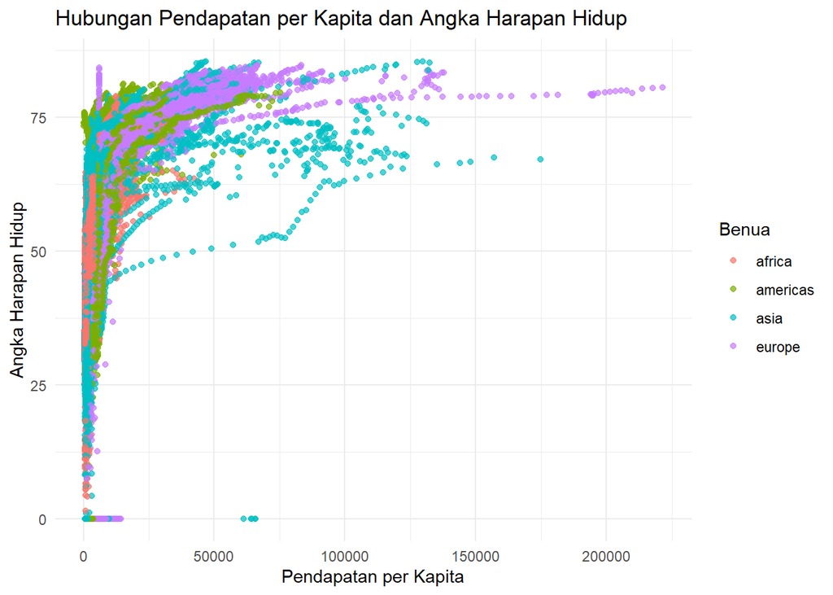

```r
library(ggplot2)
ggplot(data, aes(x = Pendapatan_per_kapita, y = Angka_Harapan_Hidup)) +
  geom_point(aes(color = Benua), alpha = 0.7) +
  labs(title = "Hubungan Pendapatan per Kapita dan Angka Harapan Hidup",
       x = "Pendapatan per Kapita",
       y = "Angka Harapan Hidup") +
  theme_minimal()
```

Interpretasi: Dari visualisasi ini, kita bisa melihat apakah ada korelasi positif antara pendapatan per kapita dan angka harapan hidup. Biasanya, negara dengan pendapatan per kapita yang lebih tinggi memiliki angka harapan hidup yang lebih tinggi.

## Grafik Multivariat

# Heatmap Rata-rata Angka Harapan Hidup per Benua dan Tahun

Heatmap ini digunakan untuk menampilkan tren rata-rata Angka Harapan Hidup di setiap benua berdasarkan tahun.

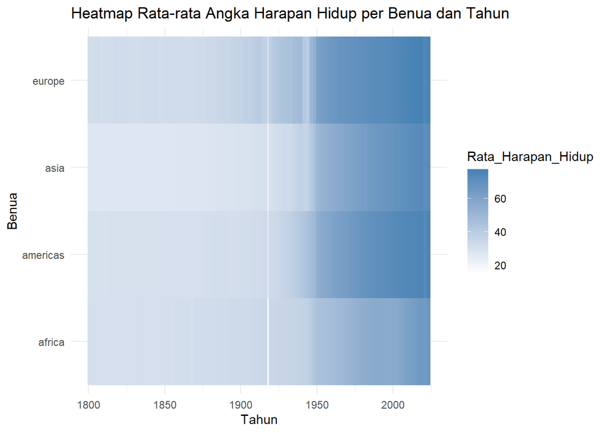

```r
library(ggplot2)
library(dplyr)
library(tidyverse)
data_heatmap <- data %>%
  group_by(Benua, Tahun) %>%
  summarise(Rata_Harapan_Hidup = mean(Angka_Harapan_Hidup, na.rm = TRUE)) %>%
  ungroup()
ggplot(data_heatmap, aes(x = Tahun, y = Benua, fill = Rata_Harapan_Hidup)) +
  geom_tile() +
  scale_fill_gradient(low = "white", high = "steelblue") +
  labs(title = "Heatmap Rata-rata Angka Harapan Hidup per Benua dan Tahun",
       x = "Tahun",
       y = "Benua") +
  theme_minimal()
```

Interpretasi: Warna pada heatmap menunjukkan rata-rata angka harapan hidup di setiap benua per tahun. Semakin gelap warna biru, semakin tinggi angka harapan hidup di wilayah tersebut.

## Grafik Interaktif

# Hubungan Pendapatan per Kapita dan Angka Harapan Hidup

```r
library(shiny)
library(ggplot2)
library(plotly)
library(readxl)
library(dplyr)

# Load data
data <- read_excel("E:/DATA VISUALITATION/UAS---Visualisai-Data/Data.xlsx")

# UI
ui <- fluidPage(
    titlePanel("Visualisasi Interaktif"),
    sidebarLayout(
        sidebarPanel(
            sliderInput("tahun", "Pilih Tahun:",
                        min = min(data$Tahun),
                        max = max(data$Tahun),
                        value = min(data$Tahun),
                        step = 1,
                        animate = animationOptions(interval = 200, loop = TRUE))
        ),
        mainPanel(
            plotlyOutput("scatterPlot")
        )
    )
)

# Server
server <- function(input, output) {
    output$scatterPlot <- renderPlotly({
        data_filtered <- data %>% filter(Tahun == input$tahun)

        p <- ggplot(data_filtered, aes(x = Pendapatan_per_kapita, y = Angka_Harapan_Hidup, color = Benua, text = Negara)) +
            geom_point(alpha = 0.7, size = 3) +
            labs(title = paste("Hubungan Pendapatan per Kapita dan Angka Harapan Hidup di Tahun", input$tahun),
                 x = "Pendapatan per Kapita",
                 y = "Angka Harapan Hidup") +
            theme_minimal()

        ggplotly(p, tooltip = "text")
    })
}

# Jalankan aplikasi
shinyApp(ui = ui, server = server)
```

Shiny applications not supported in static R Markdown documents

Interpretasi: Visualisasi ini membantu memahami hubungan antara Pendapatan per Kapita suatu negara dan Angka Harapan Hidup warganya. Secara umum, negara dengan Pendapatan per Kapita yang lebih tinggi cenderung memiliki Angka Harapan Hidup yang lebih tinggi, mencerminkan kualitas hidup yang lebih baik. Namun, hubungan ini dapat dipengaruhi oleh berbagai faktor, termasuk kebijakan kesehatan, pendidikan, dan infrastruktur sosial. Dengan menggunakan plot interaktif, pengguna dapat mengeksplorasi data lebih dalam dan mendapatkan wawasan tentang negara-negara tertentu berdasarkan informasi yang ditampilkan.

## Kesimpulan